# Activity Improvement

## Summary

In this project the goal was to predict how well a subject is performing a weight lifting exercice based on accelerator data gathered from different parts of the body.

Approach:

1. Loading datasets exploring the dataset structure and features
2. Cleaning dataset from unusable columns for analysis
3. Performing feature selection, excluding highly correlated features
4. Calculating the baseline for the model
5. Building an interpretable first classifier
6. Building a more complex classifier

Packages used:

ggplot2, dplyr, mlbench, caret, parallel, doParallel

Predictors:

data from accelerometers on the belt, forearm, arm, and dumbell of 6 participants

Outcomes:

- exactly according to the specification (Class A)
- throwing the elbows to the front (Class B)
- lifting the dumbbell only halfway (Class C)
- lowering the dumbbell only halfway (Class D)
- throwing the hips to the front (Class E)

## Background

Using devices such as Jawbone Up, Nike FuelBand, and Fitbit it is now possible to collect a large amount of data about personal activity relatively inexpensively. These type of devices are part of the quantified self movement – a group of enthusiasts who take measurements about themselves regularly to improve their health, to find patterns in their behavior, or because they are tech geeks. One thing that people regularly do is quantify how much of a particular activity they do, but they rarely quantify how well they do it. In this project, your goal will be to use data from accelerometers on the belt, forearm, arm, and dumbell of 6 participants. They were asked to perform barbell lifts correctly and incorrectly in 5 different ways. More information is available from the website here: http://groupware.les.inf.puc-rio.br/har (see the section on the Weight Lifting Exercise Dataset).

(From exercice description)

## 1. Exploratory Analysis

We will begin the analysis by acquiring the training and testing data.

```r
# training <- read.csv("https://d396qusza40orc.cloudfront.net/predmachlearn/pml-training.csv")
# testing <- read.csv("https://d396qusza40orc.cloudfront.net/predmachlearn/pml-testing.csv")
# write.csv(training, "data/training.csv")
# write.csv(testing, "data/testing.csv")

data <- read.csv("data/training.csv")
courseTesting <- read.csv("data/testing.csv")

set.seed(1991)
trainingIndex <- createDataPartition(y = data$classe, p = 0.7, list = FALSE)
training <- data[trainingIndex,]
testing <- data[-trainingIndex,]
```

The training data is of a high dimension having 13737 observations and 161 variables

```r
dim(training)
```

```
## [1] 13737   161
```

When plotting the classe-variable that serves as an outcome in the model, we see that A - doing the exercice correctly, is the most common outcome. It will serve as a good baseline prediction. We also see that even tho there are some small imbalances between the ouctomes in the dataset, all of the classes have sufficient amount of examples.

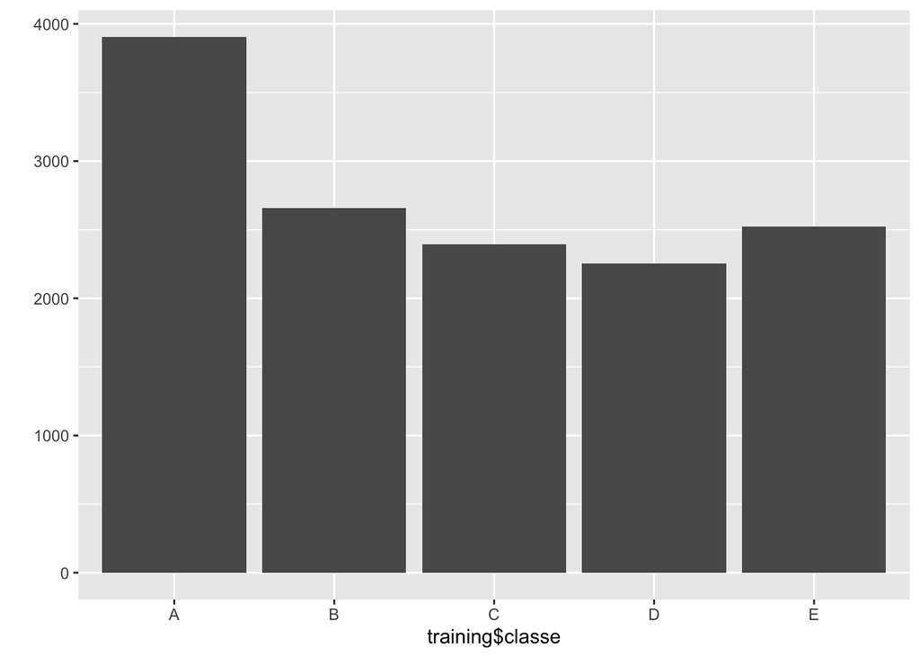

When looking at the different columns of the dataset, we see that there are some columns that are used for book keeping in the dataset. Columns 1-8 seem to be of this type.

```r
str(training[,1:10])
```

```
## 'data.frame':    13737 obs. of  10 variables:
##  $ X.1                 : int  2 3 5 6 8 12 13 15 16 17 ...
##  $ X                   : int  2 3 5 6 8 12 13 15 16 17 ...
##  $ user_name           : Factor w/ 6 levels "adelmo","carlitos",..: 2 2 2 2 2 2 2 2 2 2 ...
##  $ raw_timestamp_part_1: int  1323084231 1323084231 1323084232 1323084232 1323084232 1323084232 1323084232 1323084232 1323084232 1323084232 ...
##  $ raw_timestamp_part_2: int  808298 820366 196328 304277 440390 528316 560359 604281 644302 692324 ...
##  $ cvtd_timestamp      : Factor w/ 20 levels "02/12/2011 13:32",..: 9 9 9 9 9 9 9 9 9 9 ...
##  $ new_window          : Factor w/ 2 levels "no","yes": 1 1 1 1 1 1 1 1 1 1 ...
##  $ num_window          : int  11 11 12 12 12 12 12 12 12 12 ...
##  $ roll_belt           : num  1.41 1.42 1.48 1.45 1.42 1.43 1.42 1.45 1.48 1.51 ...
##  $ pitch_belt          : num  8.07 8.07 8.07 8.06 8.13 8.18 8.2 8.2 8.15 8.12 ...
```

## 2. Cleaning Data

### Removing book keeping columns

We will start the cleaning of the dataset, by removing the book keeping columns.

```r
training <- select(training, -c(X:num_window))
testing <- select(testing, -c(X:num_window))
courseTesting <-  select(courseTesting, -c(X:num_window))
```

### Removing NA columns

After removing the book keeping columns we will have a look on how much NA-values are included in each column.

```r
table(colSums(is.na(training)) / dim(training)[1])
```

```
##
##                 0 0.978088374463129
##                87                67
```

We see that 67 columns contain mainly NA-values. We will exclude these columns out.

```r
noNaColumns <- colSums(is.na(training)) / dim(training)[1] == 0

training <- training[, noNaColumns]
testing <- testing[, noNaColumns]
courseTesting <- courseTesting[, noNaColumns]
```

### Removing empty string columns

Next we will check how much there are columns that contain "" -values.

```r
table(colSums(training == "") / dim(training)[1])
```

```
##
##                 0 0.978088374463129
##                54                33
```

From the remaining columns there are 33 that contain mainly ""-values. We will exclude these columns out.

```r
noEmptyColumns <- colSums(training == "") / dim(training)[1] == 0
training <- training[, noEmptyColumns]
testing <- testing[, noEmptyColumns]
courseTesting <- courseTesting[, noEmptyColumns]
```

## 2. Building a Model

### Feature Selection

This far we have already managed to drop the number of features from 161 to 54. Next we will investgate if we can exclude even more features for making the model faster, understandable and to decrease the variance of the model.

```r
correlationMatrix <- cor(training[,1:52])
highlyCorrelated <- findCorrelation(correlationMatrix, cutoff=.75)
highlyCorrelated
```

```
##  [1] 11  2 10 23  5 37  9 12 38 36 39 22 35 24 26 14 49 47 32 34 19
```

We will exclude these columns out.

```r
training <- training[,-highlyCorrelated]
testing <- testing[,-highlyCorrelated]
courseTesting <-courseTesting[,-highlyCorrelated]
dim(training)
```

```
## [1] 13737    33
```

### Baseline

As our baseline accuracy we will use a dummy model that predicts always “A”, wchich was the most common outcome in the dataset.

```r
y <- training$classe
mfreq <- sort(table(training$classe),decreasing=TRUE)[1]
base <- mfreq/length(y)
base
```

```
##         A
## 0.2843416
```

With only predicting “A”, we will get an accuracy of 0.2843416

### K-Nearest Neighbors - An Interpretable Predictor

As the first model we will build a K-Nearest-Neighbors predictor. We chose this as our first model for it is extremely easy to exlpain and interprete.

Due to the large sample size and long running time, we used parallell processing in the training to make the training process faster.

In the K-Fold Cross Validation we chose the number of folds to be 10 due to the large amount of observations (>10000) in the dataset.

```r
# library(parallel)
# library(doParallel)
#
# cluster <- makeCluster(detectCores() - 1) # convention to leave 1 core for OS
# registerDoParallel(cluster)
#
# train_control <- trainControl(method="cv", number=10, allowParallel = TRUE)
# model <- train(classe ~ ., method="knn", data=training, trControl=train_control)
# saveRDS(model, "model.rds")
#
# stopCluster(cluster)
# registerDoSEQ()
```

```r
model <-readRDS("model.rds")
```

Even with this very simple model we get an almost perfect testing accuracy of 0.998 with the cross validation.

```r
model
```

```
## k-Nearest Neighbors
##
## 13737 samples
##    32 predictor
##     5 classes: 'A', 'B', 'C', 'D', 'E'
##
## No pre-processing
## Resampling: Cross-Validated (10 fold)
## Summary of sample sizes: 12363, 12364, 12364, 12366, 12363, 12363, ...
## Resampling results across tuning parameters:
##
##   k  Accuracy   Kappa
##   5  0.9983256  0.9978822
##   7  0.9978162  0.9972378
##   9  0.9965057  0.9955801
##
## Accuracy was used to select the optimal model using the largest value.
## The final value used for the model was k = 5.
```

```r
model$resample
```

```
##     Accuracy     Kappa Resample
## 1  0.9992717 0.9990787   Fold02
## 2  0.9992722 0.9990796   Fold01
## 3  0.9985433 0.9981573   Fold03
## 4  0.9978166 0.9972381   Fold06
## 5  0.9985444 0.9981590   Fold05
## 6  0.9970824 0.9963097   Fold04
## 7  0.9985433 0.9981575   Fold07
## 8  0.9978198 0.9972427   Fold10
## 9  0.9985444 0.9981591   Fold09
## 10 0.9978182 0.9972401   Fold08
```

Accuracy with testing set

```r
pred1 <- predict(model, testing)
confusionMatrix(pred1, testing$classe)
```

```
## Confusion Matrix and Statistics
##
##           Reference
## Prediction    A    B    C    D    E
##          A 1674    0    0    0    0
##          B    0 1136    1    0    0
##          C    0    3 1025    0    0
##          D    0    0    0  964    1
##          E    0    0    0    0 1081
##
## Overall Statistics
##
##                Accuracy : 0.9992
##                  95% CI : (0.998, 0.9997)
##     No Information Rate : 0.2845
##     P-Value [Acc > NIR] : < 2.2e-16
##
##                   Kappa : 0.9989
##
##  Mcnemar's Test P-Value : NA
##
## Statistics by Class:
##
##                      Class: A Class: B Class: C Class: D Class: E
## Sensitivity            1.0000   0.9974   0.9990   1.0000   0.9991
## Specificity            1.0000   0.9998   0.9994   0.9998   1.0000
## Pos Pred Value         1.0000   0.9991   0.9971   0.9990   1.0000
## Neg Pred Value         1.0000   0.9994   0.9998   1.0000   0.9998
## Prevalence             0.2845   0.1935   0.1743   0.1638   0.1839
## Detection Rate         0.2845   0.1930   0.1742   0.1638   0.1837
## Detection Prevalence   0.2845   0.1932   0.1747   0.1640   0.1837
## Balanced Accuracy      1.0000   0.9986   0.9992   0.9999   0.9995
```

The outcomes seem to be very clearly distinctive based on the features used in the training data, giving an out-of-sample accuracy of 0.9992. Due to this we would actually not need to use a more complex algortihm for training, bu we will repeat the process with random forest model out of curiosity and practice.

### Random Forest model

We repeat the same training process as with KNN classifier. The only difference is that we replace the method to be random forest and we pre-process the data before giving it to the classifier.

```r
# library(parallel)
# library(doParallel)
#
# cluster <- makeCluster(detectCores() - 1) # convention to leave 1 core for OS
# registerDoParallel(cluster)
#
# train_control <- trainControl(method="cv", number=10, allowParallel = TRUE)
# model2 <- train(classe ~ ., method="rf", preProcess = c("center", "scale"), data=training, trControl=train_control)
# saveRDS(model, "model2.rds")
#
# stopCluster(cluster)
# registerDoSEQ()
```

```r
model2 <-readRDS("model2.rds")
```

As with the KNN-classifier we get a near perfect accuracy with random forest classifier.

```r
model2
```

```
## Random Forest
##
## 13737 samples
##    32 predictor
##     5 classes: 'A', 'B', 'C', 'D', 'E'
##
## Pre-processing: centered (32), scaled (32)
## Resampling: Cross-Validated (10 fold)
## Summary of sample sizes: 12363, 12364, 12363, 12364, 12364, 12364, ...
## Resampling results across tuning parameters:
##
##   mtry  Accuracy   Kappa
##    2    0.9994903  0.9993554
##   17    1.0000000  1.0000000
##   32    0.9997815  0.9997236
##
## Accuracy was used to select the optimal model using the largest value.
## The final value used for the model was mtry = 17.
```

```r
model2$resample
```

```
##    Accuracy Kappa Resample
## 1         1     1   Fold02
## 2         1     1   Fold01
## 3         1     1   Fold04
## 4         1     1   Fold03
## 5         1     1   Fold06
## 6         1     1   Fold05
## 7         1     1   Fold08
## 8         1     1   Fold07
## 9         1     1   Fold10
## 10        1     1   Fold09
```

Accuracy with testing set

```r
pred2 <- predict(model2, testing)
confusionMatrix(pred2, testing$classe)
```

```
## Confusion Matrix and Statistics
##
##           Reference
## Prediction    A    B    C    D    E
##          A 1674    0    0    0    0
##          B    0 1137    0    0    0
##          C    0    2 1026    0    0
##          D    0    0    0  964    0
##          E    0    0    0    0 1082
##
## Overall Statistics
##
##                Accuracy : 0.9997
##                  95% CI : (0.9988, 1)
##     No Information Rate : 0.2845
##     P-Value [Acc > NIR] : < 2.2e-16
##
##                   Kappa : 0.9996
##
##  Mcnemar's Test P-Value : NA
##
## Statistics by Class:
##
##                      Class: A Class: B Class: C Class: D Class: E
## Sensitivity            1.0000   0.9982   1.0000   1.0000   1.0000
## Specificity            1.0000   1.0000   0.9996   1.0000   1.0000
## Pos Pred Value         1.0000   1.0000   0.9981   1.0000   1.0000
## Neg Pred Value         1.0000   0.9996   1.0000   1.0000   1.0000
## Prevalence             0.2845   0.1935   0.1743   0.1638   0.1839
## Detection Rate         0.2845   0.1932   0.1743   0.1638   0.1839
## Detection Prevalence   0.2845   0.1932   0.1747   0.1638   0.1839
## Balanced Accuracy      1.0000   0.9991   0.9998   1.0000   1.0000
```

With the Random Forest classifier we are able to improve the out-of-sample accuracy slightly from 0.9992 -> 0.9997

## Conclusion

In the project we were able to get excellent results with both with KNN -classifier and Random Forest -classifier. The smallest out-of-sample error received with the Randomg Forest classifier was 0.0003